# Ejercicios Modelos lineales

## Ejercicio 1: Modelo regresión

Tenemos un dataset con riqueza de especies en las islas Galápagos. Nos preguntamos si hay un efecto de la variable área de la isla, elevación máxima de la isla y distancia a la isla más próxima en la riqueza de especies.

Variables:

- Area: área de la isla
- Elevation: elevación máxima de la isla
- Nearest: distancia isla más próxima
- Species: riqueza de especies

Pasos que seguir

1. Instalar y cargar el paquete faraway (data(gala))
2. Representar gráficamente relación variable respuesta con las variables explicativas y correlación variables
3. Ajustar modelo lineal
4. Interpretación resultados modelo
5. Comprobación supuestos del modelo

### Instalar paquete y cargar los datos

```r
library(faraway)
data(gala)
head(gala)
```

```
             Species Endemics  Area Elevation Nearest Scruz Adjacent
Baltra            58       23 25.09       346     0.6   0.6     1.84
Bartolome         31       21  1.24       109     0.6  26.3   572.33
Caldwell           3        3  0.21       114     2.8  58.7     0.78
Champion          25        9  0.10        46     1.9  47.4     0.18
Coamano            2        1  0.05        77     1.9   1.9   903.82
Daphne.Major      18       11  0.34       119     8.0   8.0     1.84
```

### 1. Análisis exploratorios

```r
library(ggplot2)
library(patchwork)
plot1 <- ggplot(data = gala, aes(x = Area , y = Species)) +
  geom_point(color = "blue", size = 1.5) +
  labs(x = "Área de la isla",
       y = "Riqueza de especies",
      title = "Relación entre riqueza de especies y área de la isla"
  ) +
  theme_minimal()
plot2 <- ggplot(data = gala, aes(x = Elevation , y = Species)) +
  geom_point(color = "red", size = 1.5) +
  labs(x = "Elevación de la isla",
       y = "",
      title = "Relación entre riqueza de especies y elevación de la isla"
  ) +
  theme_minimal()
plot3 <- ggplot(data = gala, aes(x = Nearest , y = Species)) +
  geom_point(color = "darkgreen", size = 1.5) +
  labs(x = "Distancia isla más próxima",
       y = "",
      title = "Relación entre riqueza de especies y distancia isla más próxima"
  ) +
  theme_minimal()
```

```r
plot1 + plot2 + plot3
```

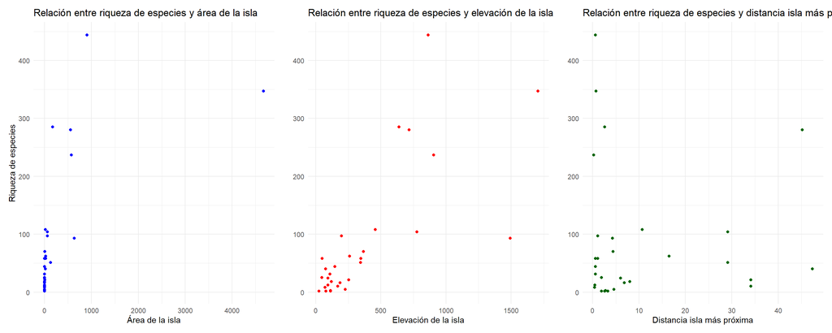

### 2. Correlación variables explicativas

```r
library(GGally)
ggcorr(gala[,c(1,3:5)], label = TRUE)
```

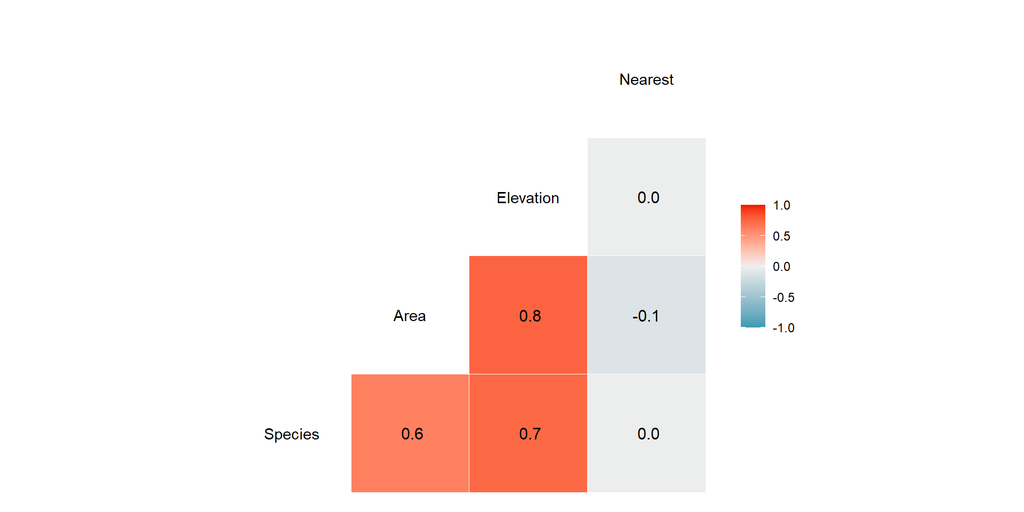

Parece relación estre riqueza especies y área y elevación. Convertir a log podría ayudar.

Relación entre área y elevación. ¿Qué se podría hacer? Quitar una.

### 3. Ajuste modelo lineal e interpretación modelo

```r
lm.gal0<-lm(Species~Area+Elevation+Nearest, gala)
anova(lm.gal0)
```

```
Analysis of Variance Table

Response: Species
          Df Sum Sq Mean Sq F value    Pr(>F)
Area       1 145470  145470 22.2592 7.076e-05 ***
Elevation  1  65664   65664 10.0476  0.003882 **
Nearest    1     29      29  0.0045  0.947179
Residuals 26 169918    6535
---
Signif. codes:  0 '***' 0.001 '**' 0.01 '*' 0.05 '.' 0.1 ' ' 1
```

### 4. Comprobación supuestos del modelo

```r
par(mfcol=c(2,2))
plot(lm.gal0)
```

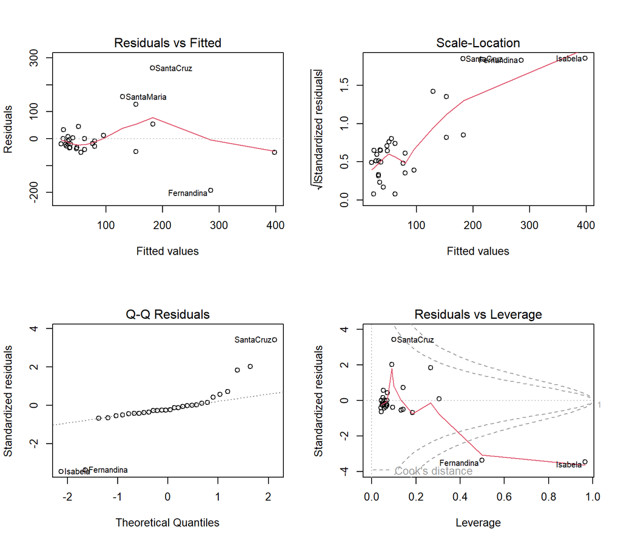

Ausencia de homocedasticidad, normalidad y linealidad. Y valores atípicos. No sirve modelo.

```r
library(car)
vif(lm.gal0)
```

```
     Area Elevation   Nearest
 2.373470  2.344460  1.025189
```

Transformación variable respuesta

```r
gala$log_Sp <- log(gala$Species)
plot1 <- ggplot(data = gala, aes(x = Area , y = log_Sp)) +
  geom_point(color = "blue", size = 1.5) +
  labs(x = "Área de la isla",
       y = "Riqueza de especies",
      title = "Relación entre riqueza de especies y área de la isla"
  ) +
  theme_minimal()
plot2 <- ggplot(data = gala, aes(x = Elevation , y = log_Sp)) +
  geom_point(color = "red", size = 1.5) +
  labs(x = "Elevación de la isla",
       y = "",
      title = "Relación entre riqueza de especies y elevación de la isla"
  ) +
  theme_minimal()
plot3 <- ggplot(data = gala, aes(x = Nearest , y = log_Sp)) +
  geom_point(color = "darkgreen", size = 1.5) +
  labs(x = "Distancia isla más próxima",
       y = "",
      title = "Relación entre riqueza de especies y distancia isla más próxima"
  ) +
  theme_minimal()
```

```r
plot1 + plot2 + plot3
```

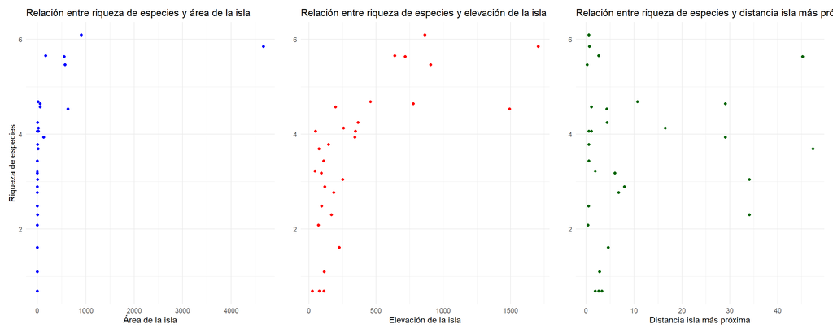

Sigue sin ser lineal la relación.

Transformación variables predictoras

```r
gala$log_Sp <- log(gala$Species)
gala$log_area <- log(gala$Area)
gala$log_elevacion <- log(gala$Elevation)
gala$log_near <- log(gala$Nearest)

plot1 <- ggplot(data = gala, aes(x = log_area , y = log_Sp)) +
  geom_point(color = "blue", size = 2) +
  labs(x = "Área de la isla",
       y = "Riqueza de especies",
      title = "Relación entre riqueza de especies y área de la isla"
  ) +
  theme_minimal()
plot2 <- ggplot(data = gala, aes(x = log_elevacion , y = log_Sp)) +
  geom_point(color = "red", size = 2) +
  labs(x = "Elevación de la isla",
       y = "",
      title = "Relación entre riqueza de especies y elevación de la isla"
  ) +
  theme_minimal()
plot3 <- ggplot(data = gala, aes(x = log_near , y = log_Sp)) +
  geom_point(color = "darkgreen", size = 2) +
  labs(x = "Distancia isla más próxima",
       y = "",
      title = "Relación entre riqueza de especies y distancia isla más próxima"
  ) +
  theme_minimal()
plot1 + plot2 + plot3
```

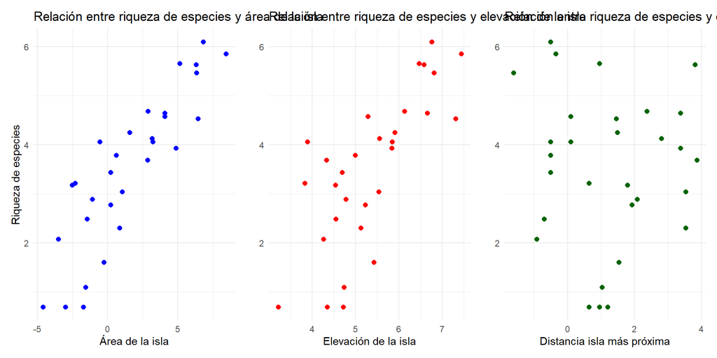

```r
plot1 + plot2 + plot3
```

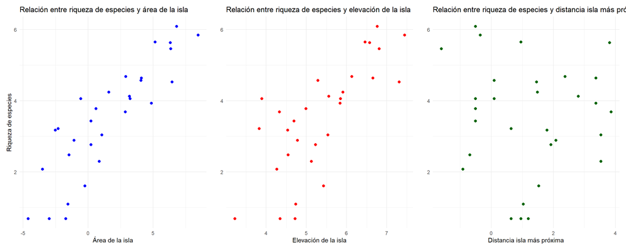

#### Ajuste modelo y comprobación supuestos

```r
lm.gal1 <- lm(log_Sp~log_area+log_elevacion+log_near, gala)
par(mfcol=c(2,2))
plot(lm.gal1)
```

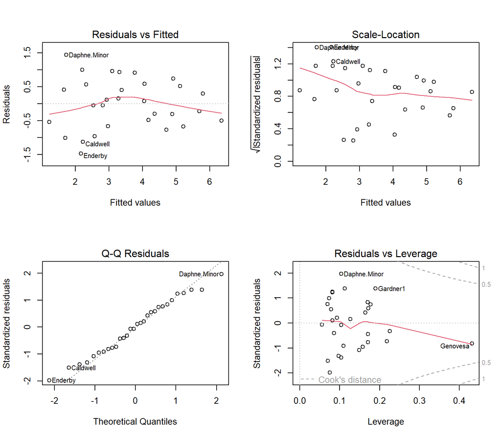

¿Jerarquización variables?

```r
library(car)
Anova(lm.gal1,type="III")
```

```
Anova Table (Type III tests)

Response: log_Sp
               Sum Sq Df F value    Pr(>F)
(Intercept)    5.4127  1  9.0225  0.005832 **
log_area      15.2592  1 25.4356 2.997e-05 ***
log_elevacion  0.6725  1  1.1210  0.299433
log_near       1.0009  1  1.6684  0.207841
Residuals     15.5978 26
---
Signif. codes:  0 '***' 0.001 '**' 0.01 '*' 0.05 '.' 0.1 ' ' 1
```

Problemas colinealidad

```r
vif(lm.gal1)
```

```
     log_area log_elevacion      log_near
     5.480281      5.461635      1.008644
```

Valor muy grande. Decidir qué variable eliminar

```r
lm.gal2 <- lm(log_Sp~log_area+log_near,gala)
Anova(lm.gal2,type="III")
```

```
Anova Table (Type III tests)

Response: log_Sp
             Sum Sq Df  F value    Pr(>F)
(Intercept) 156.581  1 259.8405 2.225e-15 ***
log_area     54.502  1  90.4448 4.123e-10 ***
log_near      0.948  1   1.5731    0.2205
Residuals    16.270 27
---
Signif. codes:  0 '***' 0.001 '**' 0.01 '*' 0.05 '.' 0.1 ' ' 1
```

Quitar distancia

```r
lm.gal3 <- lm(log_Sp~log_area,gala)
Anova(lm.gal3,type="III")
```

```
Anova Table (Type III tests)

Response: log_Sp
             Sum Sq Df F value    Pr(>F)
(Intercept) 210.109  1 341.676 < 2.2e-16 ***
log_area     53.668  1  87.274  4.23e-10 ***
Residuals    17.218 28
---
Signif. codes:  0 '***' 0.001 '**' 0.01 '*' 0.05 '.' 0.1 ' ' 1
```

```r
summary(lm.gal3)
```

```
Call:
lm(formula = log_Sp ~ log_area, data = gala)

Residuals:
    Min      1Q  Median      3Q     Max
-1.5442 -0.4001  0.0941  0.5449  1.3752

Coefficients:
            Estimate Std. Error t value Pr(>|t|)
(Intercept)   2.9037     0.1571  18.484  < 2e-16 ***
log_area      0.3886     0.0416   9.342 4.23e-10 ***
---
Signif. codes:  0 '***' 0.001 '**' 0.01 '*' 0.05 '.' 0.1 ' ' 1

Residual standard error: 0.7842 on 28 degrees of freedom
Multiple R-squared:  0.7571,    Adjusted R-squared:  0.7484
F-statistic: 87.27 on 1 and 28 DF,  p-value: 4.23e-10
```

*log(Species) = 2.9 + 0.39 log(Area)*

Gráfico de predicciones

```r
library(broom)
library(tidyverse)
library(dplyr)
preds <- augment(lm.gal3, type.predict = "response", se_fit = TRUE)
preds <- preds %>%
  mutate(lower = .fitted - 1.96 * .se.fit,upper = .fitted + 1.96 * .se.fit)

ggplot(data = preds, aes(x = log_area, y = log_Sp)) +
  geom_point(color = "blue", size = 2) +
  geom_line(aes(y = .fitted)) +
  geom_ribbon(aes(ymin = lower, ymax = upper), alpha = 0.2) +
  labs(x = "Área de la isla",
       y = "Riqueza de especies",
      title = "Predicciones modelo de regresión"
  ) +
  theme_minimal()
```

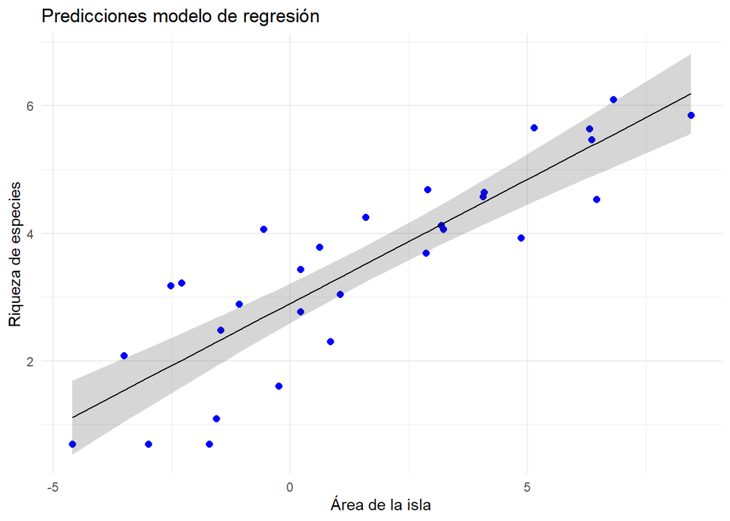

## Ejercicio 2: Modelo factorial

Tenemos un dataset con biomasa leñosa en un área mediterránea. Nos preguntamos si hay un efecto de la variable cobertura arbórea considerando dos niveles de sequía estival.

Variables:

- biomasa: biomasa leñosa
- cobertura: cobertura arbórea
- sequia: sequía o lluvia estival

Pasos que seguir

1. Cargar los datos (cobertura.csv)
2. Representar gráficamente relación variable respuesta con las variables explicativas
3. Ajustar modelo lineal
4. Interpretación resultados modelo
5. Comprobación supuestos del modelo

### Instalar paquete y cargar los datos

```r
cobertura <- read.csv("cobertura.csv")
head(cobertura)
```

```
  X  biomasa cobertura sequia
1 1 44.99793  18.55938   seco
2 2 24.05575  24.14701   seco
3 3 62.48798  68.89674   seco
4 4 47.19165  30.01684   seco
5 5 52.97670  31.25460   seco
6 6 54.23581  38.79990   seco
```

### 1. Análisis exploratorios

```r
library(ggplot2)
library(patchwork)
ggplot(cobertura, aes(x = biomasa, y = cobertura)) +
  geom_point(color = "steelblue", size = 2) +
  geom_smooth(method = "lm", se = FALSE, color = "red") +
  facet_wrap(~ sequia) +
  labs(
    title = "Relación biomasa leñosa y cobertura arbórea",
    x = "Cobertura arbórea",
    y = "Biomasa leñosa"
  ) +
  theme_minimal()
```

[figure not shown]

#### Ajuste modelo de regresión

```r
cobertura <- cobertura %>%
  mutate(sequia = as.factor(sequia))
lm_bio1 <- lm(biomasa ~ cobertura*sequia, data = cobertura)
```

#### Comprobación de hipótesis

```r
anova(lm_bio1)
```

```
Analysis of Variance Table

Response: biomasa
                  Df Sum Sq Mean Sq  F value    Pr(>F)
cobertura          1 169328  169328 1149.130 < 2.2e-16 ***
sequia             1  28187   28187  191.286 < 2.2e-16 ***
cobertura:sequia   1   7224    7224   49.023 3.936e-11 ***
Residuals        196  28881     147
---
Signif. codes:  0 '***' 0.001 '**' 0.01 '*' 0.05 '.' 0.1 ' ' 1
```

#### Supuestos del modelo

```r
par(mfrow=c(2,2))
plot(lm_bio1)
```

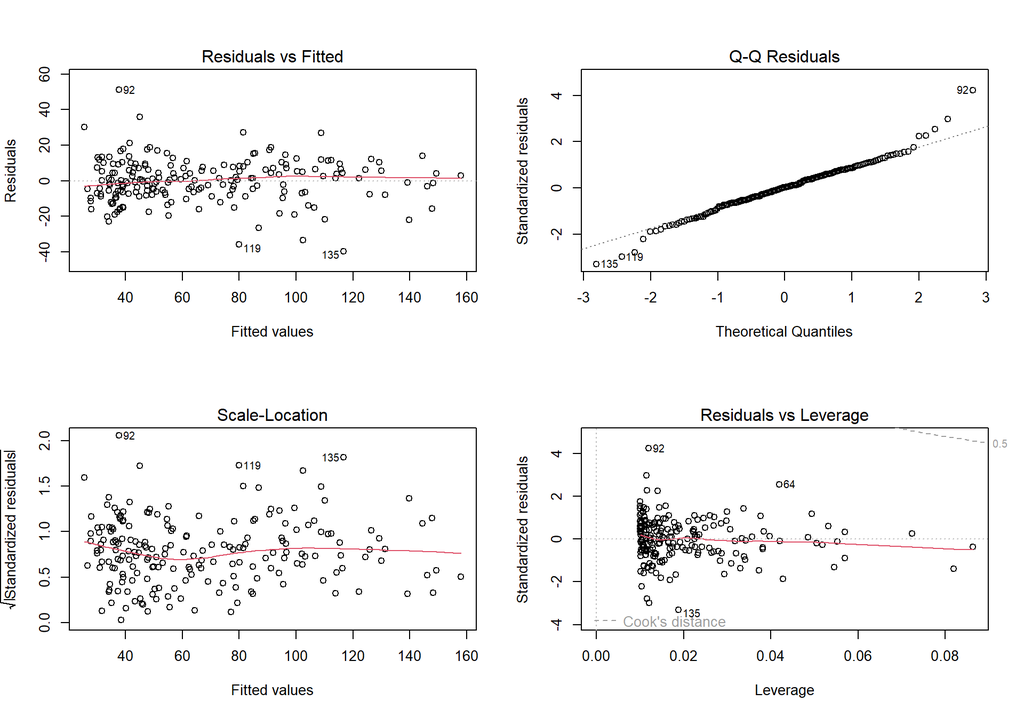

```r
summary(lm_bio1)
```

```
Call:
lm(formula = biomasa ~ cobertura * sequia, data = cobertura)

Residuals:
    Min      1Q  Median      3Q     Max
-39.708  -6.943   0.206   7.332  51.094

Coefficients:
                     Estimate Std. Error t value Pr(>|t|)
(Intercept)          25.91031    3.26354   7.939 1.54e-13 ***
cobertura             1.33964    0.06143  21.808  < 2e-16 ***
sequiaseco           -1.78935    4.20599  -0.425    0.671
cobertura:sequiaseco -0.72258    0.10320  -7.002 3.94e-11 ***
---
Signif. codes:  0 '***' 0.001 '**' 0.01 '*' 0.05 '.' 0.1 ' ' 1

Residual standard error: 12.14 on 196 degrees of freedom
Multiple R-squared:  0.8764,    Adjusted R-squared:  0.8745
F-statistic: 463.1 on 3 and 196 DF,  p-value: < 2.2e-16
```

#### Gráfica de predicciones

```r
library(broom)
newdata <- expand.grid(
  cobertura = seq(min(cobertura$cobertura), max(cobertura$cobertura), length.out = 100),
  sequia = levels(cobertura$sequia)
)
predicciones_grid <- augment(lm_bio1, newdata = newdata)

ggplot(cobertura, aes(x = cobertura, y = biomasa, color = sequia)) +
  geom_point(alpha = 0.5) +
  geom_line(data = predicciones_grid, aes(x= cobertura, y = .fitted, group = sequia, color = sequia), size = 1.2) +
  scale_color_manual(values = c("#B3E5FC", "#F8BBD0")) +
  labs(
    title = "ANCOVA: predicciones por nivel de sequía",
    x = "Cobertura",
    y = "Biomasa",
    color = "Sequía"
  ) +
  theme_minimal()
```

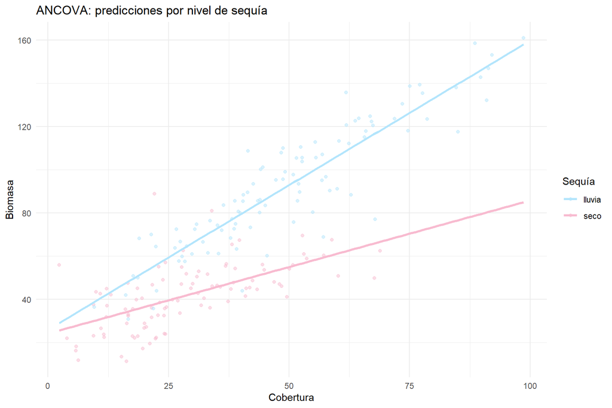